# Projet analyse de séries chronologiques

```
                                           Lilia HARIRECHE
                                               MLDS-FA
```

L’objectif de ce projet d’analyse de séries chronologiques est d’apprendre à: tracer, examiner et préparer des séries pour la modélisation et la prévision via un processus d’évaluation et d’itération. Pour cela, nous avons utilisé un ensemble de données contenant le nombre horaire et quotidien de vélos de location entre les années 2011 et 2012 dans le système de partage de vélos Capital à Washington avec les informations météorologiques et saisonnières correspondantes.

Dans ce projet, nous allons se baser sur 3 parties principales: **la description du jeu de données**, **la notion de smoothing**, et **le forcasting avec ARIMA models**.

# **1. Description du jeu de données**

## **Librairies**

```r
library(dplyr)
library(lubridate)
library(tseries)
library(forecast)
library(TTR)
```

## **Chargement des données**

```r
day <- read.csv("day.csv",stringsAsFactors=TRUE)
dim(day)
```

```
## [1] 731  16
```

```r
head(day)
```

```
##   instant     dteday season yr mnth holiday weekday workingday weathersit
## 1       1 2011-01-01      1  0    1       0       6          0          2
## 2       2 2011-01-02      1  0    1       0       0          0          2
## 3       3 2011-01-03      1  0    1       0       1          1          1
## 4       4 2011-01-04      1  0    1       0       2          1          1
## 5       5 2011-01-05      1  0    1       0       3          1          1
## 6       6 2011-01-06      1  0    1       0       4          1          1
##       temp    atemp      hum windspeed casual registered  cnt
## 1 0.344167 0.363625 0.805833 0.1604460    331        654  985
## 2 0.363478 0.353739 0.696087 0.2485390    131        670  801
## 3 0.196364 0.189405 0.437273 0.2483090    120       1229 1349
## 4 0.200000 0.212122 0.590435 0.1602960    108       1454 1562
## 5 0.226957 0.229270 0.436957 0.1869000     82       1518 1600
## 6 0.204348 0.233209 0.518261 0.0895652     88       1518 1606
```

## **1.1. How do the temperatures change across the seasons? What are the mean and median temperatures?**

Nous allons d’abord convertir la température et créer la colonne *raw.temp*, car les données de température étaient divisées en 41. Ainsi selon l’UCI nous avons : *1:winter, 2:spring, 3:summer, 4:fall*

```r
# Converting the nomalized temperature
day$raw.temp <- (day$temp*41)
head(day)
```

```
##   instant     dteday season yr mnth holiday weekday workingday weathersit
## 1       1 2011-01-01      1  0    1       0       6          0          2
## 2       2 2011-01-02      1  0    1       0       0          0          2
## 3       3 2011-01-03      1  0    1       0       1          1          1
## 4       4 2011-01-04      1  0    1       0       2          1          1
## 5       5 2011-01-05      1  0    1       0       3          1          1
## 6       6 2011-01-06      1  0    1       0       4          1          1
##       temp    atemp      hum windspeed casual registered  cnt  raw.temp
## 1 0.344167 0.363625 0.805833 0.1604460    331        654  985 14.110847
## 2 0.363478 0.353739 0.696087 0.2485390    131        670  801 14.902598
## 3 0.196364 0.189405 0.437273 0.2483090    120       1229 1349  8.050924
## 4 0.200000 0.212122 0.590435 0.1602960    108       1454 1562  8.200000
## 5 0.226957 0.229270 0.436957 0.1869000     82       1518 1600  9.305237
## 6 0.204348 0.233209 0.518261 0.0895652     88       1518 1606  8.378268
```

```r
dim(day)
```

```
## [1] 731  17
```

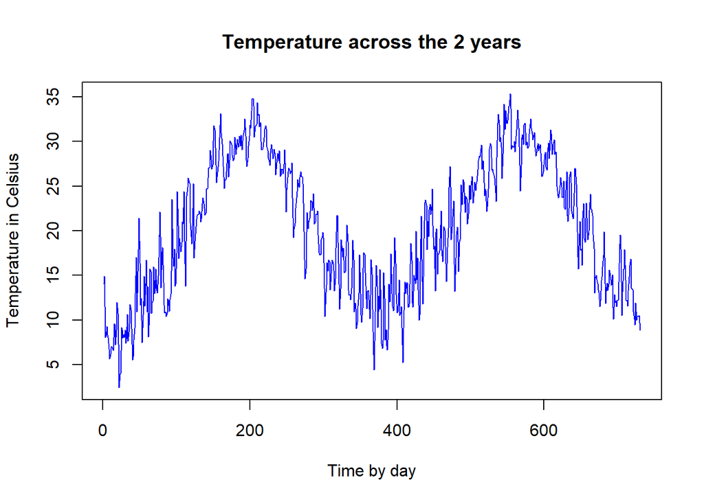

```r
day.temp <- ts(day$raw.temp)
plot(day.temp, main = "Temperature across the 2 years", ylab="Temperature in Celsius", col="blue", xlab="Time by day")
```

- Pour plus de détail sur comment les températures changent durant toutes les saisons, nous allons calculer la moyenne, la médiane et l’écart type de toutes les saisons, puis faire des visualisations graphiques que nous pourrions interpréter.

```r
#Calculating Median, Mean and Standard deviation of winter.
winter <- subset(day, season == 1)$raw.temp
wi.mean <- mean(winter)
wi.median <- median(winter)
wi.sd <- sd(winter)

#Calculating Median, Mean and Standard deviation of spring.
spring <- subset(day, season == 2)$raw.temp
sp.mean <- mean(spring)
sp.median <- median(spring)
sp.sd <- sd(spring)

#Calculating Median, Mean and Standard deviation of summer.
summer <- subset(day, season == 3)$raw.temp
su.mean <- mean(summer)
su.median <- median(summer)
su.sd <- sd(summer)

#Calculating Median, Mean and Standard deviation of fall.
fall <- subset(day, season == 4)$raw.temp
fa.mean <- mean(fall)
fa.median <-median(fall)
fa.sd <- sd(fall)
```

Comme nous pouvons le voir dans l’analyse ci dessus, la température est relativement élevée en toutes saisons, nous avons ainsi obtenu les résultats suivants:

Winter: La température moyenne en hiver est: 12.21. La température mediane en hiver est: 11.72. La derivation standard de la température en hiver est: 4.21. Spring: La température moyenne en printemps est: 22.32. La température mediane en printemps est: 23.05. La derivation standard de la température en printemps est: 5.03. Summer: La température moyenne en été est: 28.96. La température mediane en été est: 29.3. La derivation standard de la température en été est: 2.9. Fall: La température moyenne en automne est: 17.34. La température mediane en automne est: 16.78. La derivation standard de la température en automne est: 4.42.

### *- Afin de visualiser les résultats obtenus précedemment, nous allons créer un histogramme affichant les températures de chaque saison, y compris des lignes pour les températures moyennes et médianes.*

[figure not shown]

```r
boxplot(subset(day, season == 1)$temp, subset(day, season == 2)$temp, subset(day, season == 3)$temp, subset(day, season == 4)$temp, col = c("green", "red", "orange", "blue"), xlab = "Spring - Summer - Fall - Winter", ylab = "Temperature")
```

Nous pouvons aussi visualiser les résultats comme ci dessous:

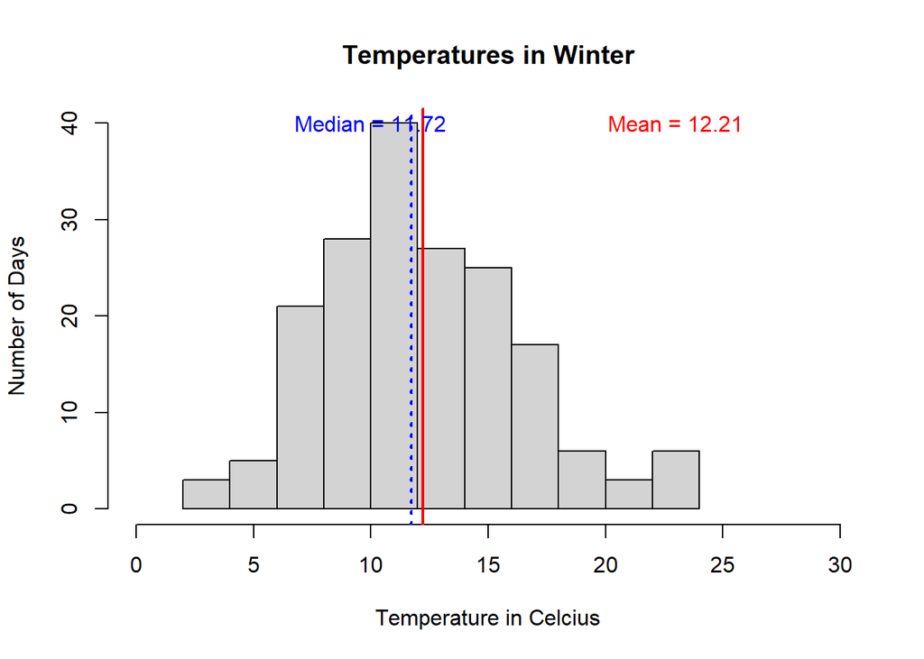

```r
#create a histogram for the distribution of temperatures in winter.
hist(x = winter,
     main = "Temperatures in Winter",
     xlab = "Temperature in Celcius",
     ylab = "Number of Days",
    xlim = c(0, 30), ylim = c(0, 40)
    )

abline(v = wi.mean, lwd = 2, lty = 1, col = "red")
text(x = 23, y = 40,
     labels = paste("Mean = ", round(mean(winter),2), sep = ""), col = "red" )

abline(v = wi.median, lwd = 2, lty = 3, col ="blue")
text(x = 10, y = 40,
     labels = paste("Median = ", round(median(winter),2), sep = ""), col ="blue" )
```

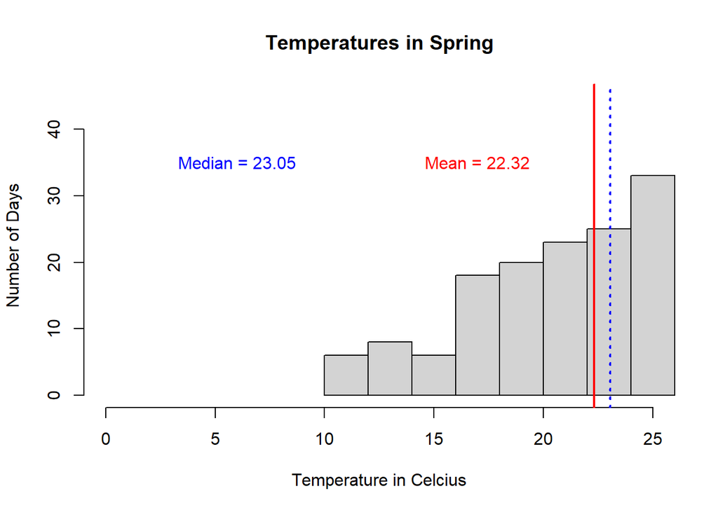

```r
#create histogram for the distribution of temperatures in spring.
hist(x = spring,
     main = "Temperatures in Spring",
     xlab = "Temperature in Celcius",
     ylab = "Number of Days",
     xlim = c(0, 25),
     ylim = c(0, 45))

abline(v = sp.mean, lwd = 2, lty = 1, col = "red")
text(x = 17, y = 35,
     labels = paste("Mean = ", round(mean(spring),2), sep = ""), col="red" )

abline(v = sp.median, lwd = 2, lty = 3, col = "blue")
text(x = 6, y = 35,
     labels = paste("Median = ", round(median(spring),2), sep = ""), col="blue" )
```

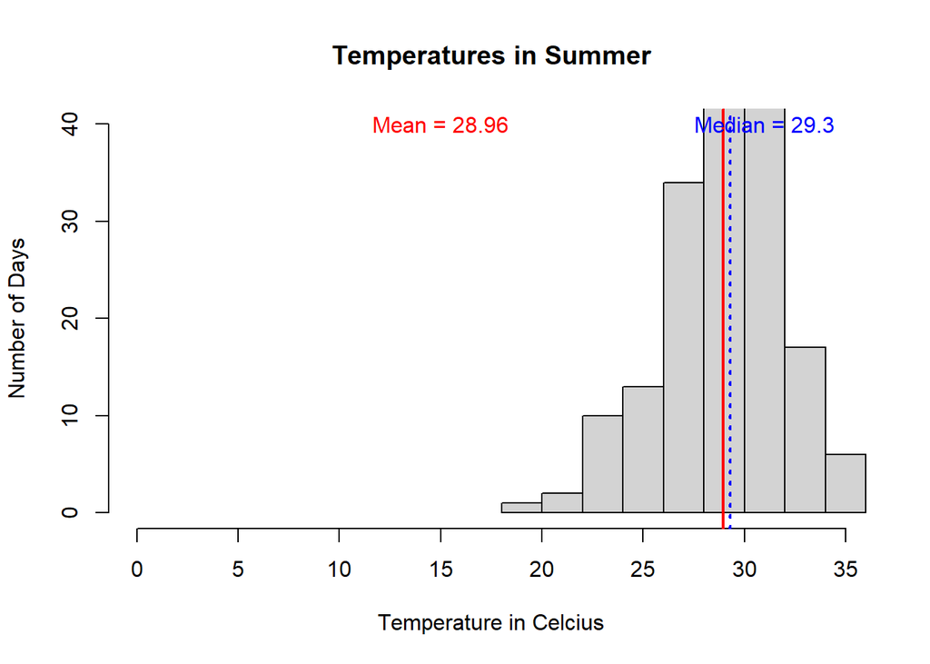

```r
#create a histogram for the distribution of temperatures in summer.
hist(x = summer,
     main = "Temperatures in Summer",
     xlab = "Temperature in Celcius",
     ylab = "Number of Days",
      xlim = c(0, 35), ylim = c(0, 40)
    )
abline(v = su.mean, lwd = 2, lty = 1, col = "red")
text( x = 15, y = 40,
     labels = paste("Mean = ", round(mean(summer),2), sep = ""),
col = "red")

abline(v = su.median, lwd = 2, lty = 3, col = "blue")
text(x = 31, y = 40,
     labels = paste("Median = ", round(median(summer),2), sep = ""), col = "blue" )
```

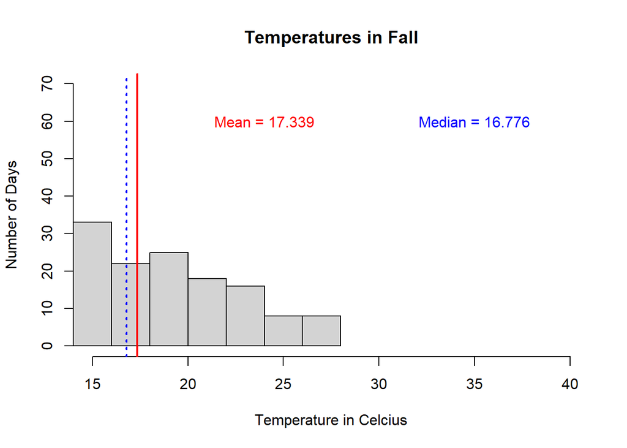

```r
#create a histogram for the distribution of temperatures in fall.
hist(x = fall,
     main = "Temperatures in Fall",
     xlab = "Temperature in Celcius",
     ylab = "Number of Days",
      xlim = c(15, 40), ylim = c(0, 70)
    )
abline(v = fa.mean, lwd = 2, lty = 1, col = "red")
text(x = 24, y = 60,
     labels = paste("Mean = ", round(mean(fall),3), sep = ""), col = "red" )

abline(v = fa.median, lwd = 2, lty = 3, col ="blue")
text(x = 35, y = 60,
     labels = paste("Median = ", round(median(fall),3), sep = ""), col ="blue" )
```

## **1.2. Is there a correlation between the temp/atemp/mean.temp.atemp and the total count of bike rentals?**

Dans cette partie nous allons d’abord vérifier l’ensemble de données NA ou NULL. Ensuite, vu que le jeu de données a déjà été recodé et corrigé, nous allons créer deux nouvelles colonnes *raw.atemp* et *raw.mean.temp.atemp*, et la fin nous allons faire un test de corrélation.

```r
#is.na(day)
#is.null(day)
```

### **- Création des nouvelles colonnes**

```r
#For this question we converted "atemp" because it was devided of 50.
day$raw.atemp <-(day$atemp * 50)

#Create a new column of the mean of raw.temp and raw.atemp.
day$raw.mean.temp.atemp <- (day$raw.temp + day$raw.atemp)/2
head(day)
```

```
##   instant     dteday season yr mnth holiday weekday workingday weathersit
## 1       1 2011-01-01      1  0    1       0       6          0          2
## 2       2 2011-01-02      1  0    1       0       0          0          2
## 3       3 2011-01-03      1  0    1       0       1          1          1
## 4       4 2011-01-04      1  0    1       0       2          1          1
## 5       5 2011-01-05      1  0    1       0       3          1          1
## 6       6 2011-01-06      1  0    1       0       4          1          1
##       temp    atemp      hum windspeed casual registered  cnt  raw.temp
## 1 0.344167 0.363625 0.805833 0.1604460    331        654  985 14.110847
## 2 0.363478 0.353739 0.696087 0.2485390    131        670  801 14.902598
## 3 0.196364 0.189405 0.437273 0.2483090    120       1229 1349  8.050924
## 4 0.200000 0.212122 0.590435 0.1602960    108       1454 1562  8.200000
## 5 0.226957 0.229270 0.436957 0.1869000     82       1518 1600  9.305237
## 6 0.204348 0.233209 0.518261 0.0895652     88       1518 1606  8.378268
##   raw.atemp raw.mean.temp.atemp
## 1  18.18125           16.146048
## 2  17.68695           16.294774
## 3   9.47025            8.760587
## 4  10.60610            9.403050
## 5  11.46350           10.384369
## 6  11.66045           10.019359
```

### **- test de corrélation**

```r
#Correlation between temp and the total count of bike rentals.
cor.temp <- cor.test(x = day$raw.temp, y = day$cnt)
cor.temp
```

```
##
##  Pearson's product-moment correlation
##
## data:  day$raw.temp and day$cnt
## t = 21.759, df = 729, p-value < 2.2e-16
## alternative hypothesis: true correlation is not equal to 0
## 95 percent confidence interval:
##  0.5814369 0.6695422
## sample estimates:
##      cor
## 0.627494
```

```r
#Nous avons récuperer ces données qui seront utilisées dans le plot des corrélations
Temperature <- day$raw.temp
Amount.Rentals <- day$cnt
```

La corrélation est de 0.63.

```r
#Correlation between atemp and the total count of bike rentals.
cor.atemp <- cor.test(x = day$raw.atemp, y = day$cnt)
cor.atemp
```

```
##
##  Pearson's product-moment correlation
##
## data:  day$raw.atemp and day$cnt
## t = 21.965, df = 729, p-value < 2.2e-16
## alternative hypothesis: true correlation is not equal to 0
## 95 percent confidence interval:
##  0.5853376 0.6727918
## sample estimates:
##       cor
## 0.6310657
```

```r
#Nous avons récuperer ces données qui seront utilisées dans le plot des corrélations
Feeled.Temperature <- day$raw.atemp
Amount.Rentals <- day$cnt
```

La corrélation est de 0.63.

```r
#Correlation between mean.temp.atemp and the total count of bike rentals.
day$raw.mean.temp.atemp <-(day$raw.temp + day$raw.atemp)/2
cor.mean.temp.atemp <- cor.test(x = day$raw.mean.temp.atemp,
y = day$cnt)
cor.mean.temp.atemp
```

```
##
##  Pearson's product-moment correlation
##
## data:  day$raw.mean.temp.atemp and day$cnt
## t = 21.941, df = 729, p-value < 2.2e-16
## alternative hypothesis: true correlation is not equal to 0
## 95 percent confidence interval:
##  0.5848953 0.6724234
## sample estimates:
##       cor
## 0.6306607
```

```r
Feeled.Raw.Temperature <- day$raw.mean.temp.atemp
Amount.Rentals <- day$cnt
```

La corrélation est de 0.63.

### **- Afin de visualiser les corrélations obtenues précedemment, nous allons utiliser la fonction plot().**

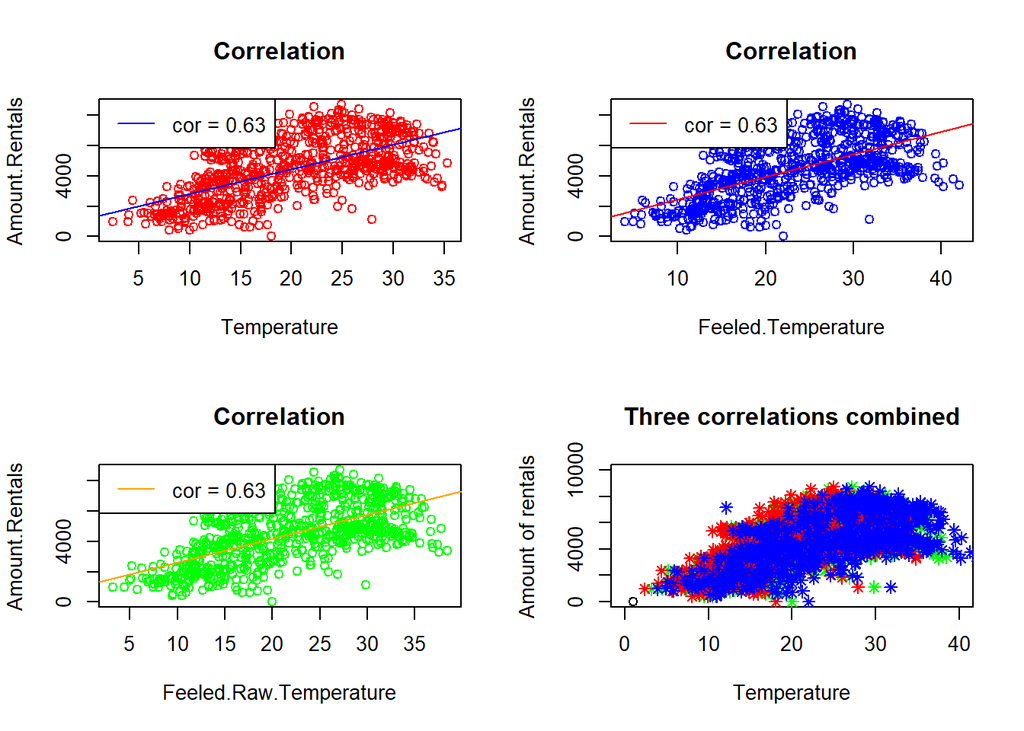

```r
par(mfrow=c(2,2))

plot(x = Temperature, y = Amount.Rentals, main = "Correlation", col = "red")
abline(lm(Amount.Rentals ~ Temperature), col = "blue")
legend("topleft",
       legend = paste("cor = ", round(cor(Temperature, Amount.Rentals), 2), sep = ""),lty = 1, col = "blue")

plot(x = Feeled.Temperature, y = Amount.Rentals, main = "Correlation", col = "blue")
abline(lm(Amount.Rentals ~ Feeled.Temperature), col = "red")
legend("topleft",
       legend = paste("cor = ", round(cor(Feeled.Temperature, Amount.Rentals), 2), sep = ""),lty = 1, col = "red")

plot(x = Feeled.Raw.Temperature, y = Amount.Rentals, main = "Correlation", col = "green")
abline(lm(Amount.Rentals ~ Feeled.Raw.Temperature), col = "orange")
legend("topleft",
       legend = paste("cor = ", round(cor(Temperature, Amount.Rentals), 2), sep = ""),lty = 1, col = "orange")


plot(x = 1, y = 1,
     xlab = "Temperature", ylab = "Amount of rentals",
     xlim = c(0, 40), ylim = c(0, 10000), main = "Three correlations combined")

points(Feeled.Raw.Temperature, Amount.Rentals, pch = 8, col = "green")
points(Temperature, Amount.Rentals, pch = 8, col = "red")
points(Feeled.Temperature, Amount.Rentals, pch = 8, col = "blue")
```

Dans cette analyse, nous avons corrélé la température brute (converted nomalized temperature), la température ressentie convertie (raw.atemp) et la moyenne des deux. Comme nous pouvons le voir dans les résultats ci dessus, les trois types de températures sont en corrélation positive avec le montant total des locations de vélos. Nous voyons également que la valeur de corrélation n’est pas différente entre les trois types de températures (cor = 0,63). Quoi qu’il en soit, l’analyse montre clairement qu’il existe une relation entre ces deux variables.

## **1.3. What are the mean temperature, humidity, windspeed and total rentals per months?**

```r
# Months is coded as 1 to 12
# Converting month with "merge"

lookup.month<- data.frame("mnth" = c(1:12),
                          "mnth.name" = c("01Jan", "02Feb", "03March", "04April", "05May", "06June", "07July", "08Aug", "09Sept", "10Oct", "11Nov", "12Dec"), stringsAsFactors = FALSE)

day <- merge(x=day, y= lookup.month, by = 'mnth')


# Convert the nomalized windspeed and humidity
day$raw.windspeed <- (day$windspeed*67)
day$raw.hum <- (day$hum * 100)
head(day)
```

```
##   mnth instant     dteday season yr holiday weekday workingday weathersit
## 1    1       1 2011-01-01      1  0       0       6          0          2
## 2    1       2 2011-01-02      1  0       0       0          0          2
## 3    1       3 2011-01-03      1  0       0       1          1          1
## 4    1       4 2011-01-04      1  0       0       2          1          1
## 5    1       5 2011-01-05      1  0       0       3          1          1
## 6    1       6 2011-01-06      1  0       0       4          1          1
##       temp    atemp      hum windspeed casual registered  cnt  raw.temp
## 1 0.344167 0.363625 0.805833 0.1604460    331        654  985 14.110847
## 2 0.363478 0.353739 0.696087 0.2485390    131        670  801 14.902598
## 3 0.196364 0.189405 0.437273 0.2483090    120       1229 1349  8.050924
## 4 0.200000 0.212122 0.590435 0.1602960    108       1454 1562  8.200000
## 5 0.226957 0.229270 0.436957 0.1869000     82       1518 1600  9.305237
## 6 0.204348 0.233209 0.518261 0.0895652     88       1518 1606  8.378268
##   raw.atemp raw.mean.temp.atemp mnth.name raw.windspeed raw.hum
## 1  18.18125           16.146048     01Jan     10.749882 80.5833
## 2  17.68695           16.294774     01Jan     16.652113 69.6087
## 3   9.47025            8.760587     01Jan     16.636703 43.7273
## 4  10.60610            9.403050     01Jan     10.739832 59.0435
## 5  11.46350           10.384369     01Jan     12.522300 43.6957
## 6  11.66045           10.019359     01Jan      6.000868 51.8261
```

```r
month.agg <- day %>% group_by(mnth.name) %>% summarise(
    mean.temp = mean(raw.temp),
    mean.hum = mean(raw.hum),
    mean.windspeed = mean(raw.windspeed),
    mean.rentals = mean(cnt))
month.agg
```

```
## # A tibble: 12 x 5
##    mnth.name mean.temp mean.hum mean.windspeed mean.rentals
##    <chr>         <dbl>    <dbl>          <dbl>        <dbl>
##  1 01Jan          9.69     58.6           13.8        2176.
##  2 02Feb         12.3      56.7           14.5        2655.
##  3 03March       16.0      58.8           14.9        3692.
##  4 04April       19.3      58.8           15.7        4485.
##  5 05May         24.4      68.9           12.3        5350.
##  6 06June        28.0      57.6           12.4        5772.
##  7 07July        31.0      59.8           11.1        5564.
##  8 08Aug         29.1      63.8           11.6        5664.
##  9 09Sept        25.3      71.5           11.1        5767.
## 10 10Oct         19.9      69.4           11.7        5199.
## 11 11Nov         15.1      62.5           12.3        4247.
## 12 12Dec         13.3      66.6           11.8        3404.
```

###*Nous allons ainsi visualiser les les différentes moyennes associées au mois*

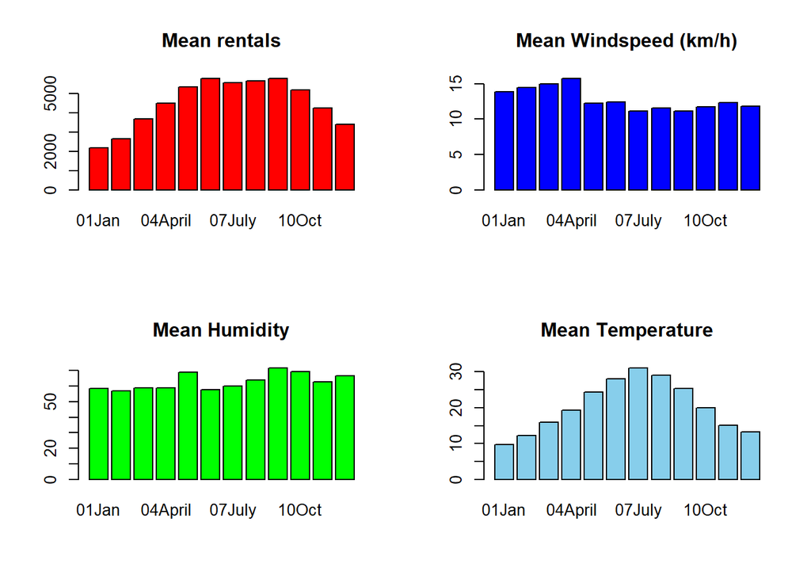

```r
par(mfrow=c(2,2))
barplot(height = month.agg$mean.rentals,
        names.arg = month.agg$mnth.name ,col = "red", main = "Mean rentals" )

barplot(height = month.agg$mean.windspeed,
        names.arg = month.agg$mnth.name,col = "blue", main = "Mean Windspeed (km/h)" )

barplot(height = month.agg$mean.hum,
        names.arg = month.agg$mnth.name,col = "green", main = "Mean Humidity" )


barplot(height = month.agg$mean.temp,
        names.arg = month.agg$mnth.name,col = "skyblue", main = "Mean Temperature" )
```

Après avoir tracé l’humidité moyenne, la température moyenne, la vitesse moyenne du vent et les locations totales moyennes par mois. Comme nous pouvons le voir, le montant total des locations de vélos augmente avec la température par mois. Alors qu’il semble que les locations soient indépendantes de la vitesse du vent et de l’humidité, car elles sont quasi constantes au fil des mois. Cela confirme également d’une part la forte corrélation entre les locations et la température et d’autre part que le beau temps pourrait être un bon prédicteur.

## **1.4. is temperature associated with bike rentals (registered vs. casual)?**

```r
# Calculating the correlation between raw.temp and registered users
cor.reg <- cor.test(x = day$raw.temp, y = day$registered)
cor.reg
```

```
##
##  Pearson's product-moment correlation
##
## data:  day$raw.temp and day$registered
## t = 17.323, df = 729, p-value < 2.2e-16
## alternative hypothesis: true correlation is not equal to 0
## 95 percent confidence interval:
##  0.4865508 0.5894440
## sample estimates:
##      cor
## 0.540012
```

```r
# Calculating the correlation between raw.temp and causal users
cor.cas <- cor.test(x = day$raw.temp,
y = day$casual)
cor.cas
```

```
##
##  Pearson's product-moment correlation
##
## data:  day$raw.temp and day$casual
## t = 17.472, df = 729, p-value < 2.2e-16
## alternative hypothesis: true correlation is not equal to 0
## 95 percent confidence interval:
##  0.4900779 0.5924581
## sample estimates:
##       cor
## 0.5432847
```

```r
#Calculating min and max
min(day$raw.temp)
```

```
## [1] 2.424346
```

```r
max(day$raw.temp)
```

```
## [1] 35.32835
```

```r
min(day$casual)
```

```
## [1] 2
```

```r
max(day$casual)
```

```
## [1] 3410
```

```r
min(day$registered)
```

```
## [1] 20
```

```r
max(day$registered)
```

```
## [1] 6946
```

Nous pourrions bien comprendre en faisant des visualisations graphiques suivantes:

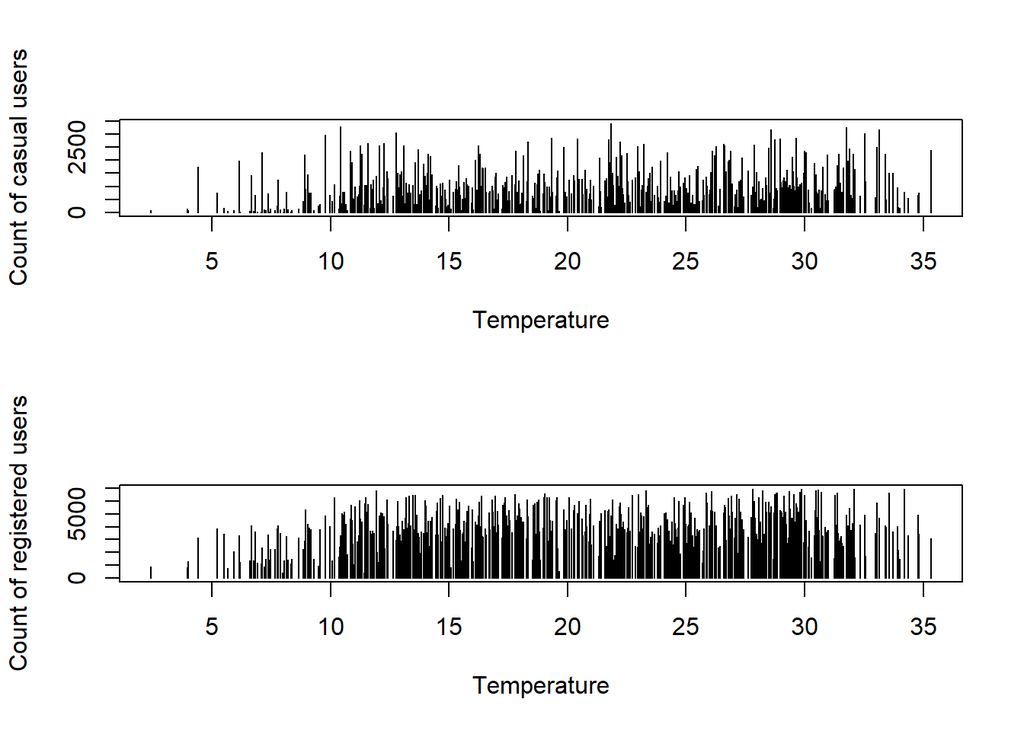

```r
day.casual <- ts(day$casual)
day.registered <- ts(day$registered)
par(mfrow=c(2,1))
plot(day.temp, day.casual, type="h", xlab="Temperature", ylab="Count of casual users")
plot(day.temp, day.registered, type="h", xlab="Temperature", ylab="Count of registered users")
```

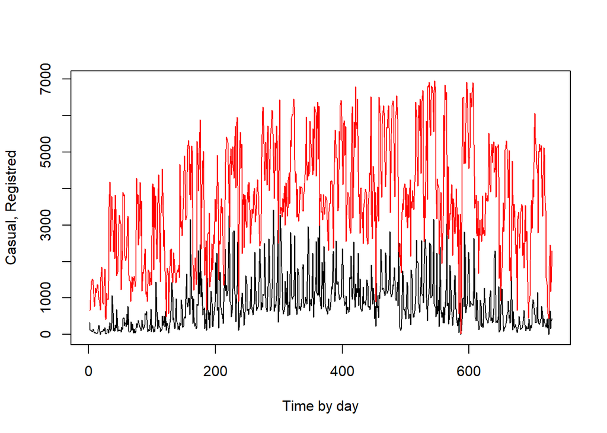

```r
seqplot.ts(day.casual, day.registered, ylab = "Casual, Registred", xlab="Time by day")
```

Nous pourrions aussi voir l’association entre temperature et bike rentals:

```r
# Plotting the association:
plot(x = 1, y = 1, xlab = "Temperature in Celcius", ylab = "Bike rentals", type = "n", main = "Association between temperature and bike rentals",
xlim = c(0, 40), ylim = c(0, 7000))

#Adding points to the plot
day$raw.temp <- (day$temp*41)
points(day$raw.temp, day$casual, pch = 16, col = "red")
points(day$raw.temp, day$registered, pch = 16, col = "skyblue")

# Adding a legend to the plot
legend("topleft",legend = c("casual", "registered"), col = c("red","skyblue"), pch = c(16, 16), bg = "white")

# Calculating the correlation between raw.temp and registered users and between raw.temp and causal users
cor.reg <- cor.test(x = day$raw.temp, y = day$registered)
cor.reg
```

```
##
##  Pearson's product-moment correlation
##
## data:  day$raw.temp and day$registered
## t = 17.323, df = 729, p-value < 2.2e-16
## alternative hypothesis: true correlation is not equal to 0
## 95 percent confidence interval:
##  0.4865508 0.5894440
## sample estimates:
##      cor
## 0.540012
```

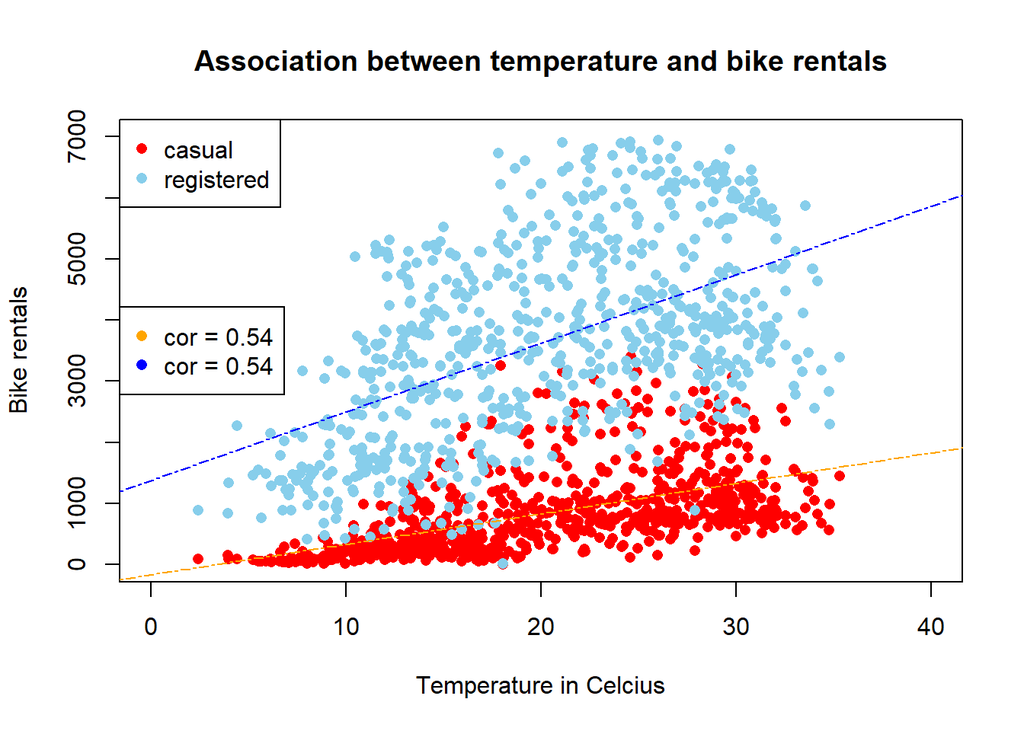

```r
# Adding Correlation line and the correlation value to the plot
abline(lm(day$registered ~ day$raw.temp), lty = 6, col = "blue")

abline(lm(day$casual ~ day$raw.temp), lty = 6, col = "orange")

reg <- paste("cor = ", round(cor(day$registered, day$raw.temp), 2), sep = "")
cas <- paste("cor = ", round(cor(day$casual, day$raw.temp), 2), sep = "")

legend("left",legend = c(cas, reg) , col = c('orange', 'blue'),pch = c(16, 16), bg = "white")
```

Nous avons recherché l’association entre les deux groupes (registered & casual) en fonction de la température. Comme nous pouvons le voir sur le graphique ci-dessus, au fur et à mesure que la température augmente, le nombre de locations de vélos augmente également chez les deux utilisateurs. Il semble que les utilisateurs enregistrés (registered) louent encore plus de vélos que les utilisateurs occasionnels (casual). C’est pourquoi nous avons calculé la corrélation entre les deux utilisateurs et la température réelle. Il montre que la corrélation est égale pour les deux groupes (cor = 0,54). La différence de présentation pourrait être biaisée en raison du nombre inégal d’utilisateurs enregistrés (max = 6946) et occasionnels (max = 3410). Cependant, le graphique confirme en partie le rôle important de la température.

## **1.5. Plot the cnt vs dteday and examine its patterns and irregularities**

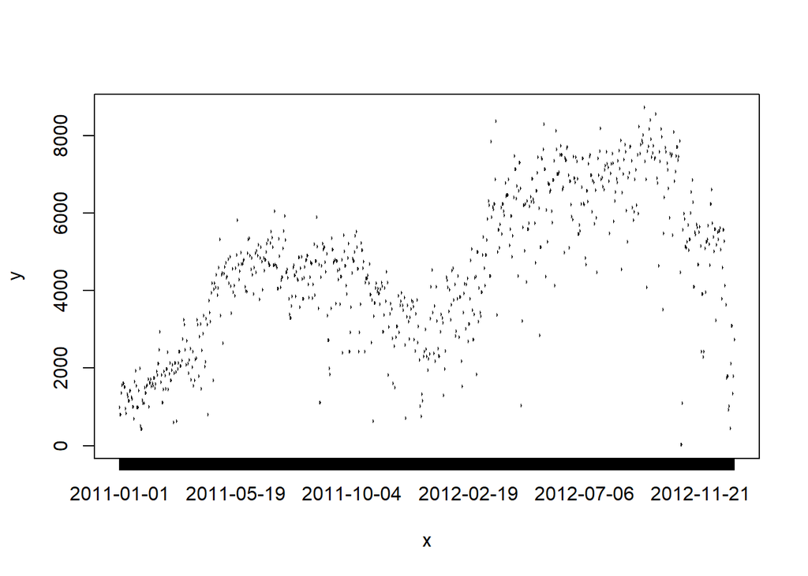

```r
par(mfrow=c(1,1))
plot(day$dteday, day$cnt, type="h", col="blue")
```

## **1.6. Clean up any outliers or missing values if needed**

Nous allons créer deux nouvelles séries chronologiques: **day.cnt.raw** contient la série chronologique initiale (avant le nettoyage) et **day.dteday** pour la dimension temporelle.

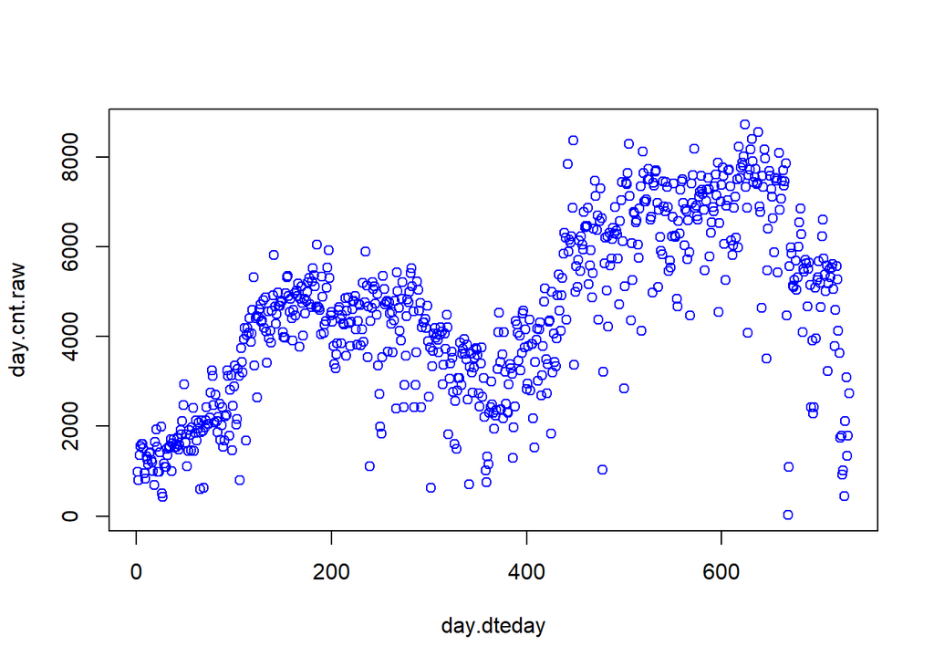

```r
day.cnt.raw <- ts(day$cnt)
day.dteday <- ts(day$dteday)
plot(day.dteday, day.cnt.raw, col="blue")
```

Ensuite, nous allons supprimer les contours en utilisant *tsclean ()*. Nous allons également extraire les valeurs aberrantes.

```r
day.cnt <- tsclean(day.cnt.raw)
outliners <- day.cnt.raw[day.cnt!=day.cnt.raw]
outliners
```

```
## integer(0)
```

## **1.7. Smoothing of time series and compare with the original**

Pour cette partie, nous allons utiliser le type de lissage suivant: Simple Exponential Smoothing

```r
day.cnt.smoothed.se <- HoltWinters(day.cnt, beta=FALSE, gamma=FALSE)
day.cnt.smoothed.se
```

```
## Holt-Winters exponential smoothing without trend and without seasonal component.
##
## Call:
## HoltWinters(x = day.cnt, beta = FALSE, gamma = FALSE)
##
## Smoothing parameters:
##  alpha: 0.6127013
##  beta : FALSE
##  gamma: FALSE
##
## Coefficients:
##       [,1]
## a 2367.057
```

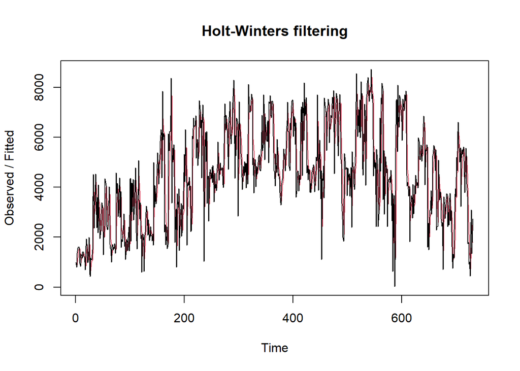

```r
plot(day.cnt.smoothed.se)
```

# **2. Using the smoothed version of cnt**

## **choose the smoothing method**

Pour cette partie, nous allons utiliser le type de lissage suivant: Simple Moving Average avec ordre 7.

Nous allons utiliser la série temporelle lissée d’ordre 7, que nous nommerons ci-après cnt_ma. Nous créons d’abord la série chronologique lissée avec l’ordre 7.

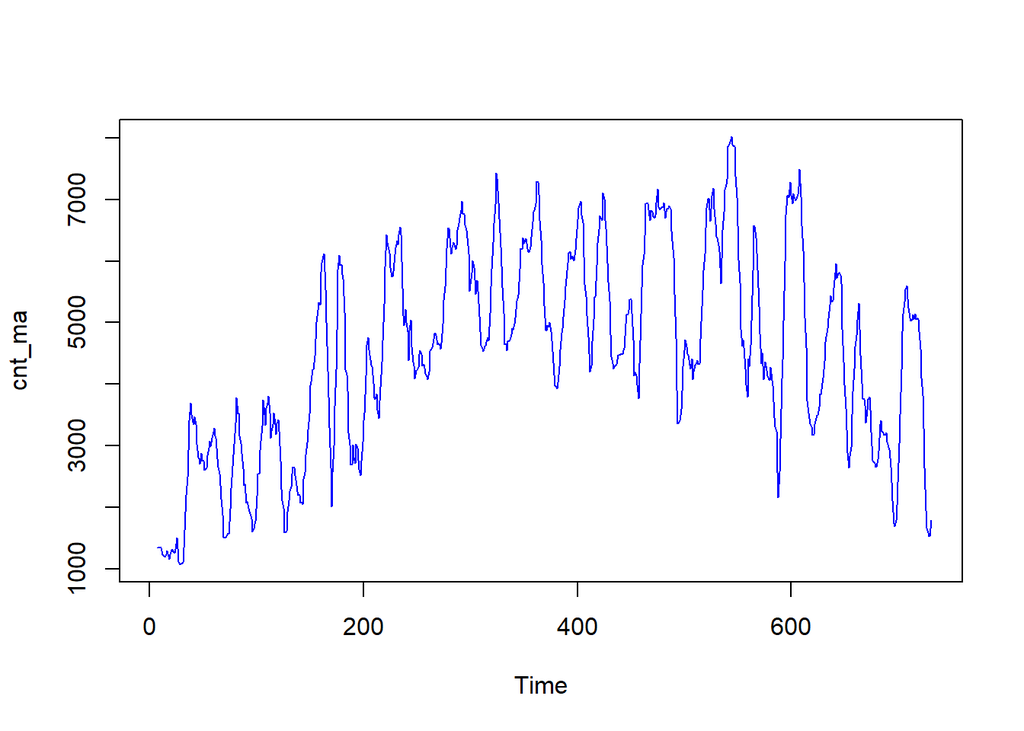

```r
cnt_ma <- SMA(day.cnt,n=7)
plot(cnt_ma, col="blue")
```

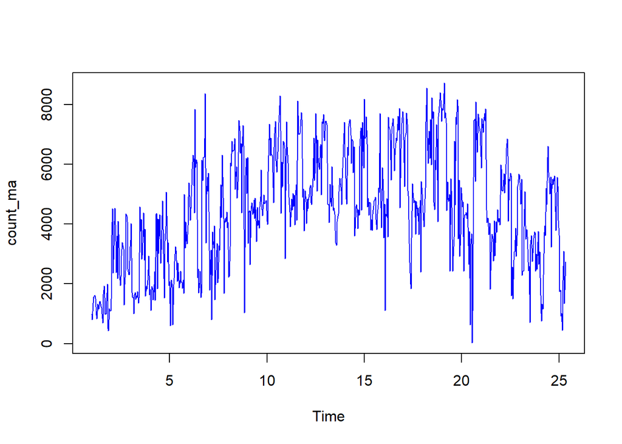

```r
count_ma <- ts(day.cnt, frequency = 30)
plot(count_ma, col="blue")
```

## **2.2.1. What could you tell about this new time series in term of seasonality?**

Oui, la série chronologique count_ma montre une tendance générale à l’augmentation des loyers au cours des deux premières saisons, puis à la diminution au cours des deux dernières saisons. La série chronologique montre également un cycle répétitif à court terme sur les deux années.

### *Utilisez decompose () pour examiner et éventuellement supprimer des composants de la série*

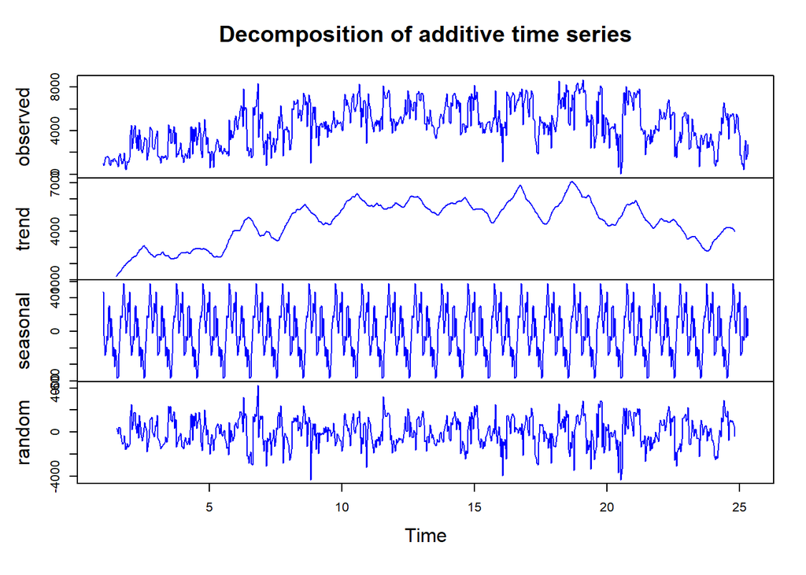

```r
count_ma.decomposed <- decompose(count_ma)
plot(count_ma.decomposed, col="blue")
```

La composante saisonnière confirme notre hypothèse et révèle un cycle mensuel saisonnié encore plus intéressant.

### *Créez une série chronologique deseasonal_cnt en supprimant le composant saisonnié*

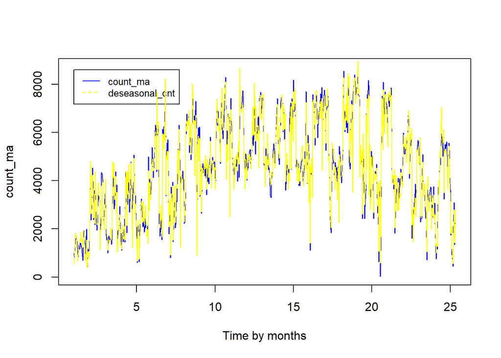

```r
deseasonal_cnt <- count_ma - count_ma.decomposed$seasonal
plot(count_ma, col = "blue", xlab="Time by months")
legend(1, 8600, legend=c("count_ma", "deseasonal_cnt"), col=c("blue", "yellow"), lty=1:2, cex=0.8)
lines(deseasonal_cnt, col = 'yellow')
```

## **2.2.2. What could you tell about this new time series in term of stationarity?**

```r
adf.test(count_ma, alternative = "stationary")
```

```
##
##  Augmented Dickey-Fuller Test
##
## data:  count_ma
## Dickey-Fuller = -4.8647, Lag order = 9, p-value = 0.01
## alternative hypothesis: stationary
```

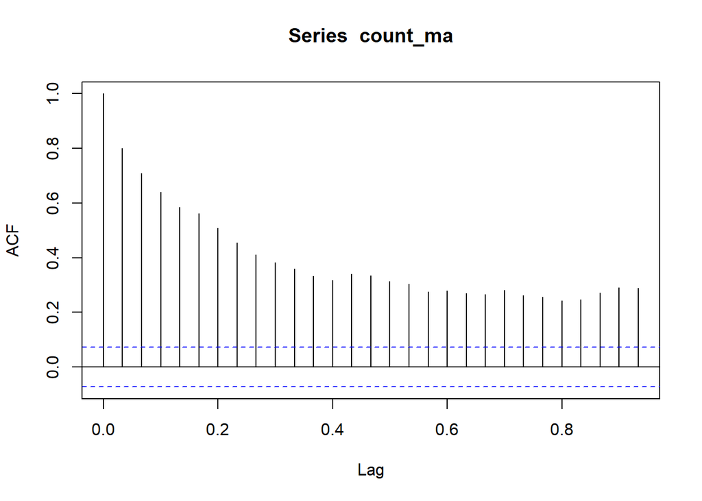

```r
acf(count_ma)
```

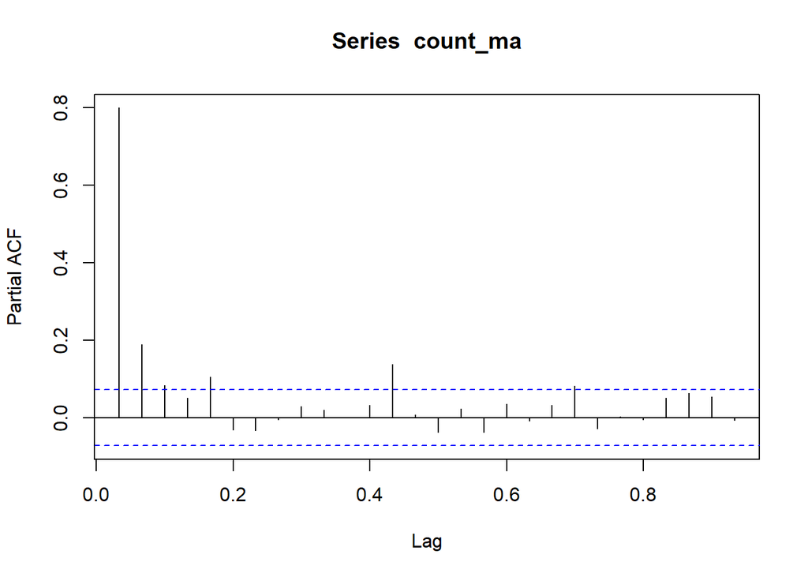

```r
pacf(count_ma)
```

### *No-Stationarity to Stationarity*

Pour rendre la série chronologique stationnaire, nous utiliserons la différenciation. La différenciation consiste à soustraire chaque point de données de la série de son successeur. Tout d’abord, nous devons savoir combien de différences sont nécessaires.

```r
count_ma.diff1 <- diff(count_ma,differences = 1)
adf.test(count_ma.diff1, alternative = "stationary")
```

```
##
##  Augmented Dickey-Fuller Test
##
## data:  count_ma.diff1
## Dickey-Fuller = -11.587, Lag order = 8, p-value = 0.01
## alternative hypothesis: stationary
```

La p-value est inférieure à 0,05. **count_ma.diff1** est stationnaire. Nous concluons que nous n’avons besoin que d’une seule différenciation pour rendre count_ma stationnaire.

# **3. Forecasting with ARIMA Models**

## **3.I. Fitting ARIMA model**

###*Fit an ARIMA model to deseasonal_cnt*

Tout d’abord, nous devons vérifier si la série chronologique a une tendance.

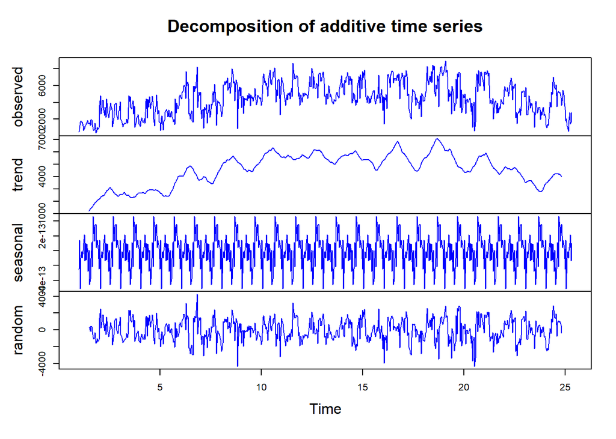

```r
deseasonal_cnt.decomposed <- decompose(deseasonal_cnt)
plot(deseasonal_cnt.decomposed, col="blue")
```

Nous vérifions maintenant si la série chronologique est stationnaire.

```r
adf.test(deseasonal_cnt, alternative = "stationary")
```

```
##
##  Augmented Dickey-Fuller Test
##
## data:  deseasonal_cnt
## Dickey-Fuller = -4.7523, Lag order = 9, p-value = 0.01
## alternative hypothesis: stationary
```

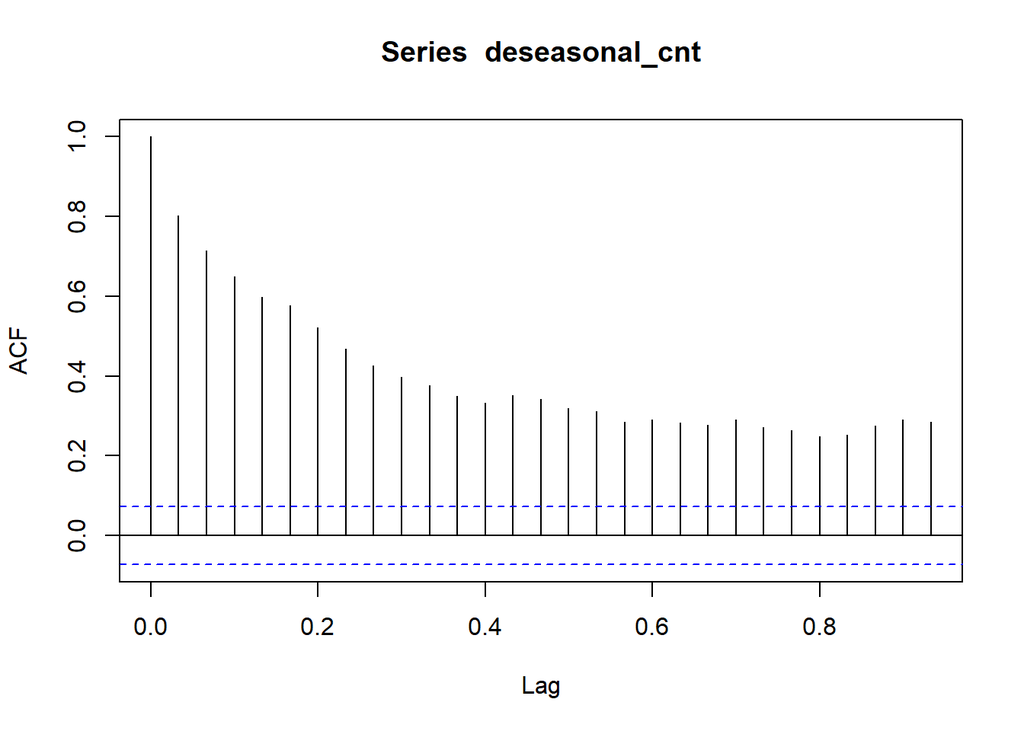

```r
acf(deseasonal_cnt)
```

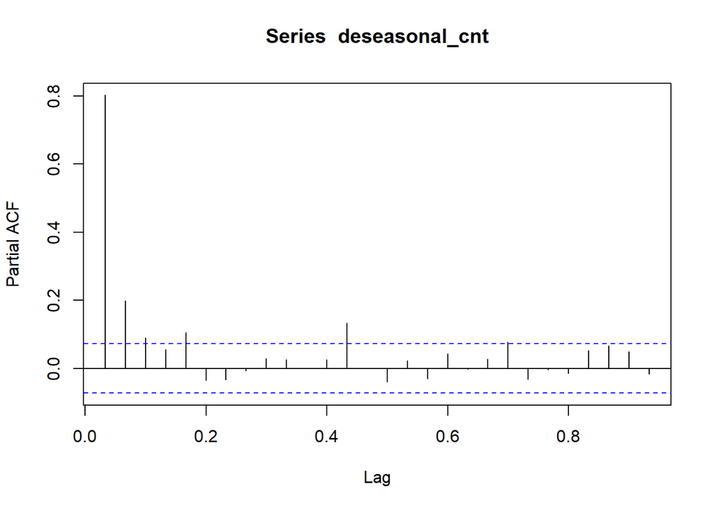

```r
pacf(deseasonal_cnt)
```

```r
deseasonal_cnt.diff1 <- diff(deseasonal_cnt,differences = 1)
adf.test(deseasonal_cnt.diff1, alternative = "stationary")
```

```
##
##  Augmented Dickey-Fuller Test
##
## data:  deseasonal_cnt.diff1
## Dickey-Fuller = -11.592, Lag order = 8, p-value = 0.01
## alternative hypothesis: stationary
```

```r
deseasonal_cnt.arima <- arima(deseasonal_cnt.diff1, order = c(6,0,8))
```

```r
deseasonal_cnt.arima
```

```
##
## Call:
## arima(x = deseasonal_cnt.diff1, order = c(6, 0, 8))
##
## Coefficients:
```

```
##          ar1     ar2      ar3     ar4     ar5      ar6      ma1      ma2
##       0.5019  0.4035  -0.1649  0.7158  0.0880  -0.5962  -0.9338  -0.3073
## s.e.     NaN     NaN   0.0755  0.1470  0.0997   0.0463      NaN      NaN
##          ma3      ma4     ma5     ma6      ma7      ma8  intercept
##       0.3188  -0.7989  0.3125  0.6719  -0.2503  -0.0068     1.1337
## s.e.     NaN   0.1946  0.1745     NaN   0.0258   0.0492     4.5844
##
## sigma^2 estimated as 1138335:  log likelihood = -6128.56,  aic = 12289.11
```

Nous pourrions suivre d’autres processus pour choisir le meilleur modèle, et donc faire plusieurs itérations.